# Analysis of NYC Subway Ridership Data

##### Udacity Data Analyst Nanodegree Project 2

#### 7/27/15

### Section 0: References

Below are websites I referrenced in making figures and performing the linear regression in the following analysis.

histogram bin sizes:  
http://stackoverflow.com/questions/6986986/bin-size-in-matplotlib-histogram http://matplotlib.org/api/pyplot_api.html#matplotlib.pyplot.legend

OLS: http://statsmodels.sourceforge.net/devel/generated/statsmodels.regression.linear_model.OLS.html

heatmap:  
http://matplotlib.org/users/text_intro.html http://stackoverflow.com/questions/14391959/heatmap-in-matplotlib-with-pcolor http://stackoverflow.com/questions/15908371/matplotlib-colorbars-and-its-text-labels http://stackoverflow.com/questions/19084476/how-to-make-matrices-in-python http://matplotlib.org/examples/pylab_examples/colorbar_tick_labelling_demo.html

### Section 1: Statistical Test

1.1 Which statistical test did you use to analyze the NYC subway data? Did you use a one-tail or a two-tail P value? What is the null hypothesis? What is your p-critical value?  
I used a Mann-Whitney U-test to analyze the difference between ridership on rainy vs. non-rainy days. By default it returns a one-tailed p-value, but can be converted to a two-tailed test by doubling this p-value. I started with the null hypothesis that the two samples come from populations with the same distribution. The p-critical value (after doubling to account for both tails) is 0.05.  
1.2 Why is this statistical test applicable to the dataset? In particular, consider the assumptions that the test is making about the distribution of ridership in the two samples.  
This test is appropriate because it does not assume that the distribution of ridership is normal, and we saw with a histogram that the distribution is likely not normal (see section 3).  
1.3 What results did you get from this statistical test? These should include the following numerical values: p-values, as well as the means for each of the two samples under test.  
The mann-whitney test gave a p-value 0.025, which we can double to get 0.05 for the two-tailed test. The mean of ridership with rain was 1105.45, and the mean without rain was 1090.28.  
1.4 What is the significance and interpretation of these results?  
At the 95% confidence level, we can just barely reject the null hyopthesis and conclude that the distributions for ridership are different with and without rain. There is only a 5% chance of getting a U-statistic that small (or smaller) for samples from identical population distributions.

### Section 2: Linear Regression

2.1 What approach did you use to compute the coefficients theta and produce prediction for ENTRIESn_hourly in your regression model:  
I used OLS regression using Statsmodels to create a linear regression model  
2.2 What features (input variables) did you use in your model? Did you use any dummy variables as part of your features?  
The features I chose were: mintempi, Hour, fog, meanwindspdi, and the UNIT as a dummy variable.  
2.3 Why did you select these features in your model? We are looking for specific reasons that lead you to believe that the selected features will contribute to the predictive power of your model.  
I chose mintempi because some measure of temp seemed important as a baseline weather measurement, and min temp slighlty increased the R2 value compared to mean or max temp. Hour was an important feature because ridership varies greatly by time of day. Fog and meanwindspdi were chosen because they represent weather factors that will influence someone's desire to ride the subway, and did a better job than rain (depsite the significance found in part 1) at improving R2. The UNIT dummy variable greatly imporved R2, so it was also included.  
2.4 What are the parameters (also known as "coefficients" or "weights") of the non-dummy features in your linear regression model?  
mintempi -12.188968  
Hour 65.391205  
fog 192.237429  
meanwindspdi 27.099674  
2.5 What is your model’s R2 (coefficients of determination) value?  
The model had an R2 of 0.481.  
2.6 What does this R2 value mean for the goodness of fit for your regression model? Do you think this linear model to predict ridership is appropriate for this dataset, given this R2 value?  
The R2 value indicates the percent of variability in ridership explained by the model - in this case only 48%, or about half. The fact that the residual variability is more than 50% tells me that this is not a great linear model for predicting ridership. In addition, the histogram of residuals (shown below) is clearly skewed right, and not normally distributed, as assumed by the model. The presence of large, non-normal residuals and low R squared value signifies that a linear model is not appropriate for this data.

```
<module 'matplotlib.pyplot' from '//anaconda/lib/python2.7/site-packages/matplotlib/pyplot.pyc'>
```

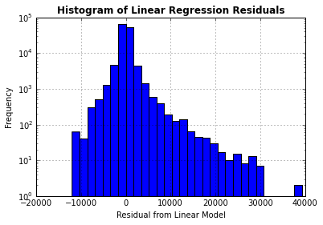

```python
import numpy as np
import pandas as pd
import statsmodels.api as sm
import scipy
import matplotlib.pyplot as plt
import math
%matplotlib inline
def linear_regression(features, values):
    features = sm.add_constant(features)
    model = sm.OLS(values, features)
    results = model.fit()
    intercept = results.params[0]
    params = results.params[1:]
    return intercept, params

def predictions(dataframe):
    features = dataframe[['mintempi', 'Hour', 'fog', 'meanwindspdi']]
    #dummy_units = pd.get_dummies(pd.Categorical.from_array(dataframe['Hour']), prefix='Hour')
    #features = features.join(dummy_units)
    dummy_units = pd.get_dummies(dataframe['UNIT'], prefix='Unit')
    features = features.join(dummy_units)
    # Values
    values = dataframe['ENTRIESn_hourly']
    # linear regression
    intercept, params = linear_regression(features, values)
    predictions = intercept + np.dot(features, params)
    return predictions

def plot_residuals(turnstile_weather, predictions):
    plt.figure()
    (turnstile_weather['ENTRIESn_hourly'] - predictions).hist(bins = 30, log='y')
    plt.title("Histogram of Linear Regression Residuals", fontweight= 'bold')
    plt.xlabel("Residual from Linear Model")
    plt.ylabel("Frequency")
    return plt

turnstile_weather = pd.read_csv('~/Desktop/P2_NYCRidershipData/turnstile_data_master_with_weather.csv')
plot_residuals(turnstile_weather, predictions(turnstile_weather))
```

### Section 3: Visualization

Below are two visualizations of the NYC Subway ridership data. The first figure shows a histogram of ridership both with and without rain. The y-axis is plotted using a log scale to make the data at higher ridership values more easily visualized. You can see the distribution is not normal, but rather has a peak close to zero and a large tail out to the right. IT also shows that there are more observations for non-rainy days than rainy days. The second figure is a heat map of ridership by day of the week and hour of the day. This figure shows that subway ridership tends to peak during weekday commuting hours, lunch, and dinner times. This visualization is a good way to look at the data, but it might be slightly misleading in this case because hourly ridership was only measured about every 4 hours each day.

```
<module 'matplotlib.pyplot' from '//anaconda/lib/python2.7/site-packages/matplotlib/pyplot.pyc'>
```

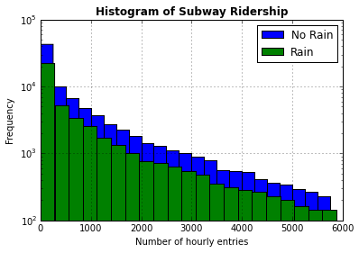

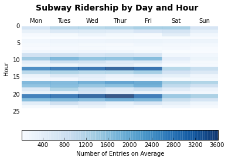

```python
import numpy as np
import pandas as pd
import matplotlib.pyplot as plt
%matplotlib inline

def entries_histogram(filename):
    turnstile_weather = pd.read_csv(filename)
    # Histogram of ridership with and without rain
    plt.figure()
    turnstile_weather.ENTRIESn_hourly[turnstile_weather['rain'] == 0].hist(bins=range(0,6000,250),log='y')
    turnstile_weather.ENTRIESn_hourly[turnstile_weather['rain'] == 1].hist(bins=range(0,6000,280), log='y')
    plt.legend(['No Rain','Rain'])
    plt.title("Histogram of Subway Ridership", fontweight= 'bold')
    plt.xlabel("Number of hourly entries")
    plt.ylabel("Frequency")
    # Finding the mean hourly entries broken down by day of week and time of day
    turnstile_weather['DATEn'] = pd.to_datetime(turnstile_weather['DATEn'])
    tw = turnstile_weather.set_index(['DATEn'])
    tw = tw[['Hour','ENTRIESn_hourly']]
    tw['DOW'] = tw.index.weekday
    data = tw.groupby(['DOW','Hour']).mean() # mean entries per dow per hour
    Matrix = np.array([[data.ENTRIESn_hourly[x,y] for x in range(7)] for y in range(24)])
    # Plotting the above data in heatmap form
    fig, ax = plt.subplots()
    heatmap = ax.pcolor(Matrix, cmap=plt.cm.Blues, alpha=0.8)
    # turn off outline grid
    ax.set_frame_on(False)
    # Adjust tick marks, title and axes
    ax.set_xticks(np.arange(Matrix.shape[1]) + 0.5, minor=False)
    ax.invert_yaxis()
    ax.xaxis.tick_top()
    labels = ['Mon','Tues','Wed','Thur','Fri','Sat','Sun']
    ax.set_xticklabels(labels, minor=False)
    ax = plt.gca()
    for t in ax.xaxis.get_major_ticks():
        t.tick1On = False
        t.tick2On = False
    for t in ax.yaxis.get_major_ticks():
        t.tick1On = False
        t.tick2On = False
    ax.set_ylabel("Hour")
    fig.suptitle("Subway Ridership by Day and Hour", fontsize=14, fontweight='bold')
    fig.subplots_adjust(top=0.85)
    # add in colorbar
    cbar = plt.colorbar(heatmap, orientation = "horizontal")
    cbar.set_label('Number of Entries on Average')
    return plt

entries_histogram('~/Desktop/P2_NYCRidershipData/turnstile_data_master_with_weather.csv')
```

### Section 4: Conclusion

The mean of ridership with rain was 1105.45, and the mean without rain was 1090.28. This suggests slightly more people tend to ride the subway when it is raining. Though we could not compare the two means with a t-test, because the distributions are not normal, we did see through the mann-whitney u-test that there is only a small probability (<5%) that ridership with and without rain come from the same population distribution. We can therefore say there is a significant difference in ridership with and without rain, with more people riding during rainy days.

Though I did not end up using rain as a feature in the linear model generated above, I did go through iterations where rain was a covariate. I ended up not including rain because I was able to achieve better r squared results with other variables, and I could only use a limited number of variables do to limitations on processing time. If rain had been included in the model, we would have seen a positive coefficient, indicating an increase in estimated/predicted ridership with rain. This agrees with the statistical test discussed above.

### Section 5: Reflections

5.1 Potential Shortcomings The mann-whitney u-test is not a direct comparison of means and it may be better to look at the median ridership numbers, since it is a rank-sum test. Even with several iterations of feature selection, the r squared value of my linear regression model stayed fairly low (<0.5). One suggestion for why this may be is that treating some of the variables as binary (rain and fog, for example), may not be the best for predicting ridership behavior. Instead, if we could collect data about the intensity of the rain or fog, we may be able to get a model using those features that has a better fit. This makes sense intuitively, since the harder it is raining or the more dense the fog, the more likely someone would want to take the subway instead of walking.

However, it is also worth considerring that there are other modes of transport (i.e. cabs, buses) and it would be very interesting to see how these modes compare to subway ridership with and without rain. Perhaps the more it rains, the more people tend to take cabs over walking or the subway. Another factor that may affect a linear model in this application is that the capacity of the subway is limited. It may be true that many more people *would* ride the suway in the rain, but it gets filled to its limits and therefore people choose to walk or take a cab, and therefore the response is no longer linear (since ridership would depend on people's perception of ridership at the time). Also, this dataset only contains one month of data, which may not be enough to create a good model of subway ridership throughout the year. A longer span of data, with more samples for rainy and non-rainy days, would give a clearer pictures of how ridership is affected.

The use of linear regression is also questionable. As discussed prior, the residuals from the model are not normally distributed, which violates an assumption of linear regression. Also, several of the independent variables in the dataset are correlated (such as the different temperatrue measures or the pressure and rain variables) which can cause collinearity and have a large affect on the coefficients of the linear model. These are just a few shortcomings in the dataset and the use of linear regression in this application.